# DS 220 – Project #2 on Data Analysis with Python – Individual or Team!

## Project #2 – **Data Analysis with Python** – An Individual or Team (max 6) Project which you

must each host on your individual Github Account

## **Group members:** Yu-Hsiang Huang, Rowan Tolfree, Nabhit Arora, Priyanshu Dey, Nathan Mannings, Cael Walter

```python
import pandas as pd
import numpy as np
from matplotlib import pyplot as plt
#make sure that the dataset is imported to the notebook
nobel = pd.read_csv('export.csv')
pd.set_option('display.max_columns', 10)
nobel
```

|  | id | firstname | surname | born | died | ... | share | motivation | name | city | country |
| --- | --- | --- | --- | --- | --- | --- | --- | --- | --- | --- | --- |
| 0 | 1 | Wilhelm Conrad | Röntgen | 1845-03-27 | 1923-02-10 | ... | 1 | "in recognition of the extraordinary services ... | Munich University | Munich | Germany |
| 1 | 2 | Hendrik A. | Lorentz | 1853-07-18 | 1928-02-04 | ... | 2 | "in recognition of the extraordinary service t... | Leiden University | Leiden | the Netherlands |
| 2 | 3 | Pieter | Zeeman | 1865-05-25 | 1943-10-09 | ... | 2 | "in recognition of the extraordinary service t... | Amsterdam University | Amsterdam | the Netherlands |
| 3 | 4 | Henri | Becquerel | 1852-12-15 | 1908-08-25 | ... | 2 | "in recognition of the extraordinary services ... | École Polytechnique | Paris | France |
| 4 | 5 | Pierre | Curie | 1859-05-15 | 1906-04-19 | ... | 4 | "in recognition of the extraordinary services ... | École municipale de physique et de chimie indu... | Paris | France |
| ... | ... | ... | ... | ... | ... | ... | ... | ... | ... | ... | ... |
| 995 | 1030 | Louis | Brus | 1943-00-00 | 0000-00-00 | ... | 3 | "for the discovery and synthesis of quantum dots" | Columbia University | New York NY | USA |
| 996 | 1031 | Aleksey | Yekimov | 1945-00-00 | 0000-00-00 | ... | 3 | "for the discovery and synthesis of quantum dots" | Nanocrystals Technology Inc. | New York NY | USA |
| 997 | 1032 | Jon | Fosse | 1959-09-29 | 0000-00-00 | ... | 1 | "for his innovative plays and prose which give... | NaN | NaN | NaN |
| 998 | 1033 | Narges | Mohammadi | 1972-04-21 | 0000-00-00 | ... | 1 | "for her fight against the oppression of women... | NaN | NaN | NaN |
| 999 | 1034 | Claudia | Goldin | 1946-00-00 | 0000-00-00 | ... | 1 | "for having advanced our understanding of wome... | Harvard University | Cambridge MA | USA |

1000 rows × 20 columns

```python
from google.colab import drive
drive.mount('/content/drive')
```

# **Question #1:** What are the Top 5 institutions with the most Nobel laureates and their top category?

```python
# Question 1: Distribution of Nobel laureates by University and find each of the top 5 university's top category

laureates_university = nobel['name'].value_counts().reset_index()
laureates_university.columns = ['University', 'Laureates Count']
laureates_university.head()

most_common_category = nobel.groupby('name')['category'].agg(lambda x: x.value_counts().idxmax())

# Join the most common category with the laureates_university DataFrame
laureates_university = laureates_university.join(most_common_category, on='University')
laureates_university.columns = ['university', 'Laureates Count', 'Top Category']

# Display the top 5 universities with their most represented category
laureates_university.head()
```

|  | university | Laureates Count | Top Category |
| --- | --- | --- | --- |
| 0 | University of California | 36 | chemistry |
| 1 | Harvard University | 28 | physics |
| 2 | Stanford University | 22 | physics |
| 3 | Massachusetts Institute of Technology (MIT) | 22 | economics |
| 4 | University of Chicago | 19 | economics |

Chemistry labs at the University of California are humming with creativity. This place is where 36 laureates have blended, poured, and changed their way to Nobel recognition, demonstrating the university's aptitude. Moving on to the East Coast, the physics department at Harvard University is revealed as a furnace of quantum and cosmic marvels with 28 total laureates. Stanford University aligns its stars in physics, where 22 laureates have contemplated the universe's deepest secrets. MIT and the University of Chicago dance cerebrally in the field of economics. With 22 and 19 laureates, respectively, their contribution to economic theory has influenced economies and policies around the world, demonstrating a deep comprehension of the fluctuations in the market. To conclude our discoveries, it is clear that the institutions are not only just good institutions. These institutions are the home of creativity, where curiosity meets opportunity. The diversity of categories of these institutions shows that it brought the most talented people and their commitment to contribute to society by solving or discovering the most mysterious side of the world.

**Question #2:** What are the trends of the gender of Nobel laureates throughout the year?

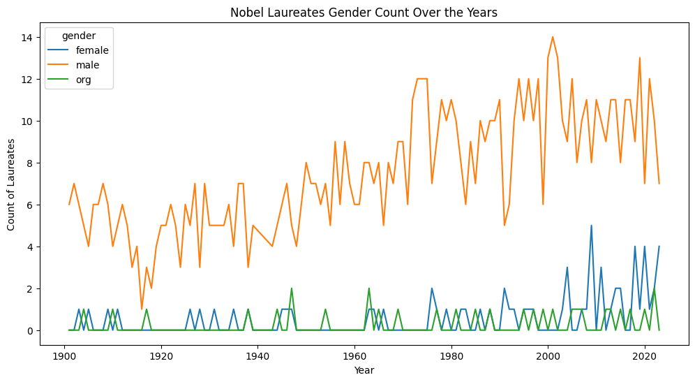

```python
%matplotlib inline
# Convert 'year' column to numeric for plotting
nobel['year'] = pd.to_numeric(nobel['year'], errors='coerce')

# Grouping by year and gender and counting the number of laureates
gender_count_by_year = nobel.groupby(['year', 'gender']).size().unstack(fill_value=0)

valid_gender_data = age_data[age_data['age_at_award'] >= 0]
# Plotting the data
gender_count_by_year.plot(kind='line', figsize=(12, 6), title='Nobel Laureates Gender Count Over the Years')
plt.xlabel('Year')
plt.ylabel('Count of Laureates')
plt.show()
```

Male laureates have overwhelmingly female and organizational winners over the years, demonstrating their dominance in the field. This is a reflection of previous gender prejudices in early research and academic sectors. Though they are less numerous, the number of female laureates has been steadily rising over time, especially in the last two decades, indicating a slow movement in the direction of gender diversity. Organizations that have received Nobel Prizes are shown by the 'org' line. These are less common and do not exhibit any discernible pattern; they most likely correlate with particular honors like the Nobel Peace Prize. With occasional changes, the general trend for male laureates is rather consistent. However, some peaks might fall in line with years when a specific finding or incident earned several honors in a row. The number of female laureates increased in the later half of the 20th century and the early 21st, suggesting the progress in the inclusion of women in fields traditionally dominated by men.

# **Question #3:** What were the top 5 countries that produced the most Nobel Prize winning Laurets and what was the top type?

```python
# Group the DataFrame by 'bornCountry' and count the number of laureates for each country
laureates_by_country = nobel.groupby(['bornCountry'])['id'].count().reset_index()

#group and find the most top category per country
category_by_country = nobel.groupby(['bornCountry'])['category'].max().reset_index()

#combine the two querries
combined = pd.merge(laureates_by_country, category_by_country, on='bornCountry', how='outer')

# Find the top 5 countries with the most laureates
top_countries = combined.nlargest(5, 'id')

#set the new column titles
top_countries.columns=['Country of birth','Prize Count','Category']

#print Graph
top_countries.head()
```

|  | Country of birth | Prize Count | Category |
| --- | --- | --- | --- |
| 116 | USA | 292 | physics |
| 120 | United Kingdom | 90 | physics |
| 46 | Germany | 67 | physics |
| 41 | France | 58 | physics |
| 109 | Sweden | 30 | physics |

When looking at the total number of laureates throughout the years 126 countries have had members of their scientific community contribute to the advancement of the worlds knowledge. When looking at each countries contributions, a couple countries stand out in quantity of laureates they have produced.

# Question #4: At what age did the winners of the Nobel Prize receive

their reward?

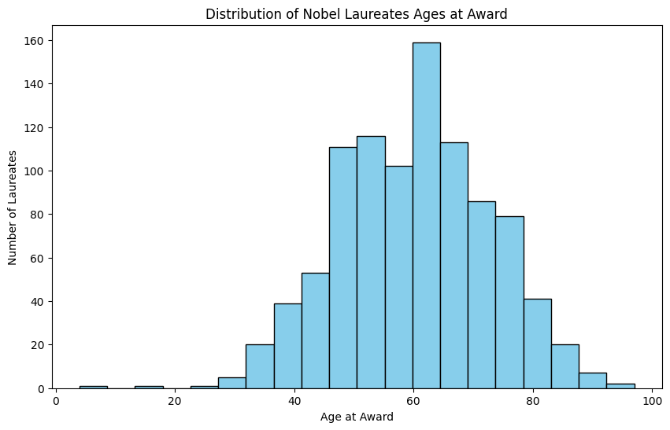

```python
# Extract relevant columns
age_data = nobel[['born', 'year']].copy()

# Convert birth_date to datetime
age_data['born'] = pd.to_datetime(age_data['born'], errors='coerce')

# Calculate age at the time of receiving the award
age_data['age_at_award'] = age_data['year'] - age_data['born'].dt.year

# Filter out invalid age values, if any
valid_age_data = age_data[age_data['age_at_award'] >= 0]

# Plotting the distribution of ages
plt.figure(figsize=(10, 6))
plt.hist(valid_age_data['age_at_award'], bins=20, color='skyblue', edgecolor='black')
plt.title('Distribution of Nobel Laureates Ages at Award')
plt.xlabel('Age at Award')
plt.ylabel('Number of Laureates')
plt.show()
```

Laureates in their 60s also represent a significant proportion, indicating that Nobel Prizes frequently honor lifetime achievements and contributions made over long careers. Younger laureates, particularly those under 40, are much less common, which may reflect the time required to make a significant impact in their respective fields that gains international recognition.

The distribution also shows that it is relatively rare for laureates to receive the award past the age of 80, which could be due to a variety of factors, including the lesser likelihood of continuing active research or the Nobel Committee's tendency to award the prize to individuals for work done in earlier stages of their careers.

Overall, the Nobel Prize appears to largely honor those who have reached a mature stage in their careers, having accumulated a body of work that has had a substantial impact on their field. This distribution aligns with the nature of the award, which is often the culmination of a lifetime of dedication to research, literature, peace efforts, or other significant contributions to society.

# **Question #5: How long has this dataset been maintained for?**

```python
# Extract the prize year column
prize_years = nobel['year']

# Find the start and end years of the dataset
start_year = prize_years.min()
end_year = prize_years.max()

print(f"The Nobel Prize dataset has been maintained from {start_year} to {end_year}.")
```

```
The Nobel Prize dataset has been maintained from 1901 to 2023.
```

In delving into the temporal dimensions of the Nobel Prize dataset, a fascinating aspect emerges regarding the dataset's longevity. Analyzing the range of prize years represented in the data offers a glimpse into the dataset's historical depth. The data spans several decades, beginning from 1901 to present, showcasing a comprehensive record of Nobel laureates over time. This extensive temporal coverage underscores the enduring effort invested in maintaining and curating the dataset. The decades-long continuity allows researchers and enthusiasts to explore the evolution of Nobel laureates and prize distributions, offering a rich resource for longitudinal studies. It's evident that the meticulous maintenance of this dataset has transformed it into a valuable repository, enabling users to uncover trends, patterns, and shifts in the landscape of Nobel Prize recipients across the years. This enduring dataset thus stands as a testament to the commitment to preserving and providing access to the remarkable legacy of Nobel laureates.

# Question #6: What is the top 5 Categories with the highest shared noble Prizes

*Priyanshu*

**Overview:**

> This section outlines the methodology used to determine which Nobel Prize categories have the most shared prizes. It explains the process of filtering and grouping the dataset to count shared prizes in each category

**Methodology:**

> For this analysis, our objective was to identify the Nobel Prize categories with the highest number of shared prizes. This can give insights into which fields tend to have collaborative work leading to Nobel-worthy discoveries. We filtered the dataset for prizes shared by laureates and then grouped these by category to count the occurrences.

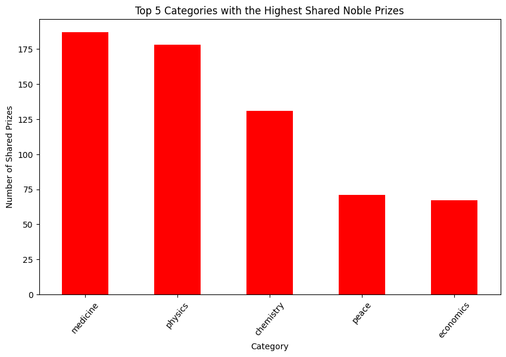

```python
'''
This code snippet performs an analyiss on the Nobel Prize dataset to find which categories
of the Nobel Prize have the highest number of shared prizes.
'''
#Filter for shared prizes
shared_prizes= nobel[nobel['share']>1]
#Group by catergory and count the shared prizes
shared_prizes_count= shared_prizes.groupby('category').size()

#Get top 5 categories with the most shared prizes
top_shared_prizes_categories= shared_prizes_count.nlargest(5)
#Print the top 5 as a graph
plt.figure(figsize=(10,6))
#choosing the color of the bars
top_shared_prizes_categories.plot(kind='bar', color='red')

#Labels for the graph
plt.title('Top 5 Categories with the Highest Shared Noble Prizes')
plt.xlabel('Category')
plt.ylabel('Number of Shared Prizes')
#adjusting the layout and setting the axis lables to 50 degres s for better viewing
plt.xticks(rotation=50)
plt.show()
```

**Findings:**

> Upon analyzing the data, we discovered that the top 5 categories in terms of shared Nobel Prizes are Medicine, Physics, Chemistry, Peace, and Economics. These results suggest that these significant scientific fields often involve collaborative research. The high number of shared prizes in these categories could indicate the complexity and scale of work in these areas, often requiring teamwork and joint efforts.

# Question #7 Which field has seen the most growth in terms of laureates over the years

*Priyanshu*

**Overview:**

> Describes the methodology for examining the growth trends of Nobel Prize categories over time. This includes calculating cumulative laureate counts and analyzing recent trends.

**Methodology:**

> We aimed to understand how the representation of different Nobel Prize categories has evolved over the years. This involved calculating the cumulative count of laureates in each category over time and analyzing the distribution of Nobel Prizes in the most recent decade.

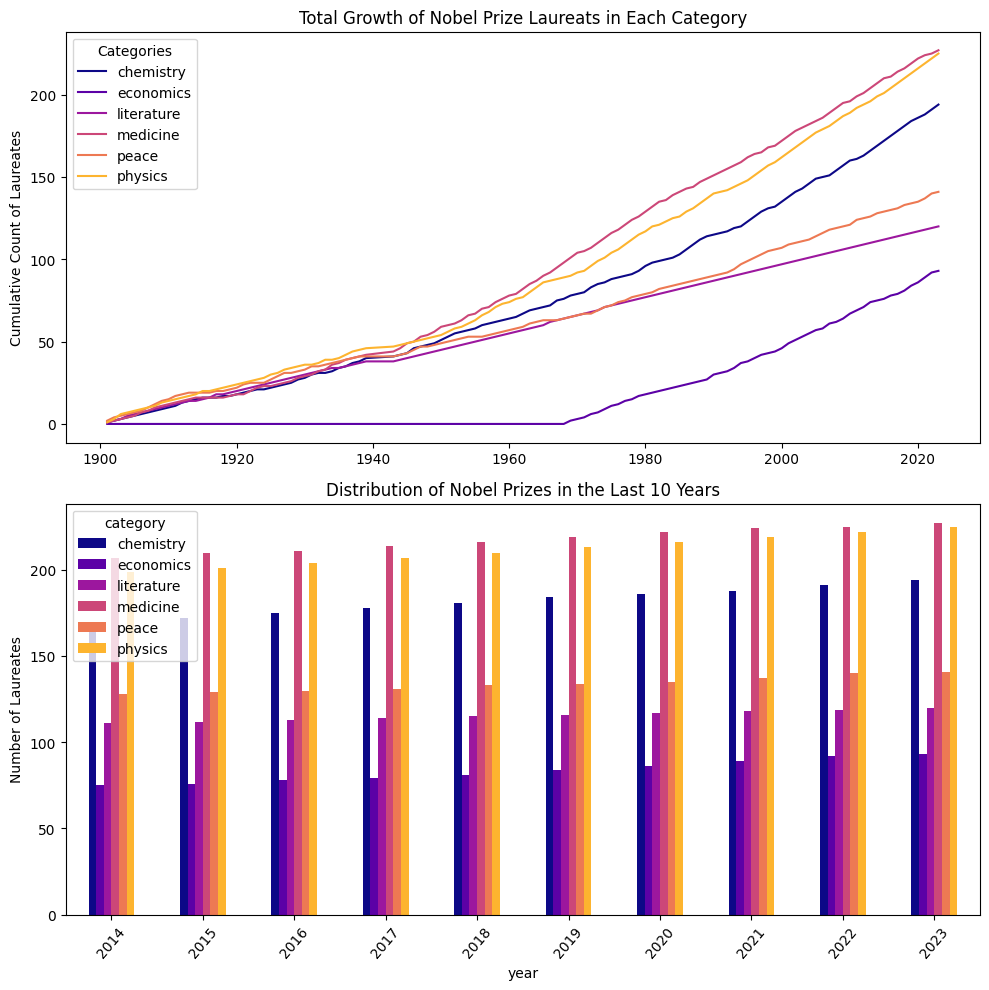

```python
'''
This code snippet is designed to visualize the growth and distribution of Nobel Prize
laureates across differnt categories over time
'''
#Group the Nobel dataset by year and category then count num of laureates in each category per year
categiry_growth= nobel.groupby(['year','category']).size().unstack(fill_value=0)
#Calculating the cumulative sum of laureates in each category over the years
total_category_growth= categiry_growth.cumsum()
#Extracting the last 10 years of data to analyze recent trends
recent_shift=total_category_growth.tail(10)
#Choosing a color map for the plot
Colormap=plt.cm.plasma
num_categories = len(total_category_growth.columns)
#Generating a list of colors from the colorpam, one for each category
colors=[Colormap(i/num_categories)for i in range(num_categories)]

#Seting up figures for two sublplots
plt.figure(figsize=(10,10))

#First Subplot: Cumlative growth of laureates in each category
plt.subplot(2,1,1)
#Creates correspoding colors for the differnt category
for category, color in zip(total_category_growth.columns,colors):
  plt.plot(total_category_growth.index,total_category_growth[category],label=category,color=color)
plt.legend(title="Categories")
plt.title('Total Growth of Nobel Prize Laureats in Each Category')
plt.ylabel('Cumulative Count of Laureates')

#Secound subplot:Distribution of Nobel Prizes in the last 30 years
plt.subplot(2,1,2)
#Calculating the number of categories for color mapping
num_categories=len(recent_shift.columns)
#Plotting the recent shift in Nobel Prizes with different colors for each
recent_shift.plot(kind='bar', ax=plt.gca(), stacked= False,color=colors)
#Ploting the Labels for each
plt.title ('Distribution of Nobel Prizes in the Last 10 Years')
plt.ylabel('Number of Laureates')

#adjusting the layout and setting the axis lables to 50 degres s for better viewing
plt.tight_layout()
plt.xticks(rotation=50)
plt.show()
```

# **Question #8:** What are the most common first three words in the laureates' award motivations?

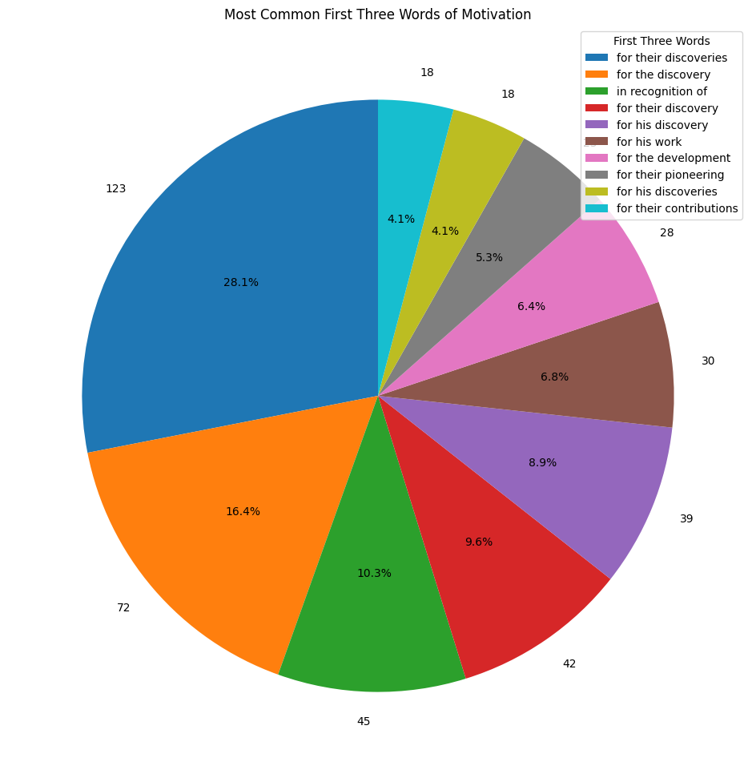

```python
#extract motivations and take only the first 3 words in each string
motivation_count=nobel.groupby(['id'],group_keys=False)['motivation'].apply(lambda group: group.str.split().apply(lambda x: ' '.join(x[:3])).apply(lambda x: x[1:]))

#count the number of times it takes for each string to occur
motivation_count=motivation_count.agg(lambda x: x.value_counts())

#move it into a df
motivation_count_df = motivation_count.reset_index(name='occurrences')

#rename columns
motivation_count_df.columns = ['first_three_words', 'occurrences']
#take only the top 10
motivation_count_df=motivation_count_df.nlargest(10, 'occurrences')

#set plot size
plt.figure(figsize=(12, 12))
#set chart
plt.pie(motivation_count_df['occurrences'], labels=motivation_count_df['occurrences'], autopct='%1.1f%%', startangle=90)
#set legend
plt.legend(motivation_count_df['first_three_words'],title='First Three Words', loc='upper right')
#set title
plt.title('Most Common First Three Words of Motivation')
```

# Question #9 Collaboration and Shared Nobel Prizes

*Nabhit Arora*

**Overview:**

> This analysis aims to explore trends in collaboration among Nobel laureates, specifically focusing on how Nobel Prizes are shared among recipients. The goal is to understand how collaborative efforts in various fields are recognized and awarded over the years.

**Methodology:**

> Group the Nobel dataset by year and category, then count the number of laureates sharing the prize each year. Analyze the distribution of shared prizes across different categories, focusing on trends over time. Compare the frequency of shared prizes in the most recent decade with historical data to identify any shifts in collaborative trends.

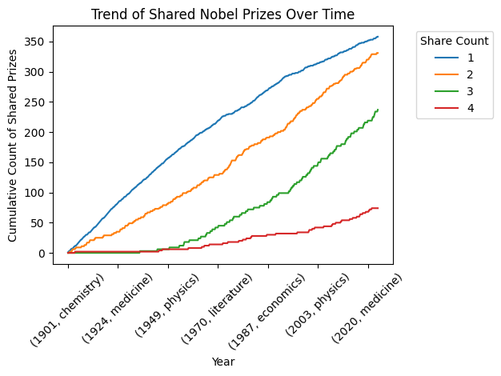

```python
# Group by year and category, count shared prizes

shared_prizes = nobel.groupby(['year', 'category']).share.value_counts().unstack(fill_value=0)

# Analyze the trend of shared prizes over time

trend_shared_prizes = shared_prizes.cumsum()

# Plotting the results

plt.figure(figsize=(12, 6))

trend_shared_prizes.plot(kind='line', title='Trend of Shared Nobel Prizes Over Time')

plt.xlabel('Year')

plt.ylabel('Cumulative Count of Shared Prizes')

plt.xticks(rotation=45)

plt.legend(title="Share Count", bbox_to_anchor=(1.05, 1), loc='upper left')

plt.tight_layout()

plt.show()
```

**Findings**

> The graph illustrates a clear trend: Nobel Prizes are increasingly being shared among laureates. Notably, prizes shared by two people (orange line) have seen the most significant increase, followed by those shared by three (green line). Single laureate prizes (blue line) still show growth, but at a slower rate. Meanwhile, prizes shared by four people (red line) are the least common, though they also show a slight increase over time.

> This trend may suggest that collaborative work is becoming more prevalent and valued across the Nobel categories. The steeper slopes for prizes shared between two or three individuals could indicate that modern scientific and academic challenges are often tackled by teams rather than individuals, possibly due to the increasing complexity of research that requires diverse expertise.

# Question #10 The impact of Institutional Affiliation on Nobel Laureates Query

*Nabhit Arora*

**Overview:**

> This study investigates the influence of institutional affiliations on Nobel laureates, identifying which institutions have been most associated with Nobel Prize-winning work and observing any changes in these trends over time.

**Methodology:**

> Extract and analyze data on the institutions associated with Nobel laureates at the time of their award. Calculate the frequency of laureates affiliated with each institution and their distribution across different Nobel categories. Examine the evolution of these affiliations over the years to detect shifts in the prominence of certain institutions.

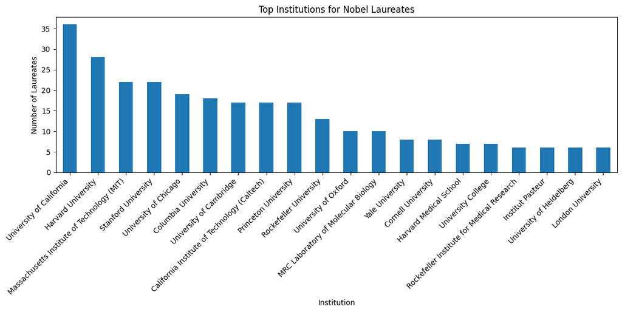

```python
# Group by institution and count laureates
institution_counts = nobel.groupby('name').id.count().sort_values(ascending=False)
# Analyze the distribution across categories
institution_category_distribution = nobel.groupby(['name', 'category']).id.count().unstack(fill_value=0)
# Plotting the top institutions
plt.figure(figsize=(12, 6))
institution_counts.head(20).plot(kind='bar', title='Top Institutions for Nobel Laureates')
plt.xlabel('Institution')
plt.ylabel('Number of Laureates')
plt.xticks(rotation=45, ha='right')
plt.tight_layout()
plt.show()
```